# psdv3

```python
import pandas as pd
import matplotlib.pyplot as plt
import seaborn as sns
```

## Spatial Aggregation [4 Marks]

1. Which state (consider all stations in that state) has the highest average PM2.5 concentration across all stations and across all years?

```python
state_avg_Pm2_5 = df.groupby('state')['PM2.5'].mean()
highest_PM2_5_state = state_avg_Pm2_5.idxmax()
print("state with highest PM2.5:",highest_PM2_5_state)
```

```
state with highest PM2.5: Delhi
```

2. Which state (consider all stations in that state) had the most days with hazardous PM2.5 levels (above 300 µg/m³) for the year 2023?

```python
df["Date"] = pd.to_datetime(df["Timestamp"])
date_2023 = df[df["Date"].dt.year == 2023]

df_hazardous = date_2023[date_2023["PM2.5"]> 300]
hazardous_days_count = df_hazardous.groupby("state").size()

hazardous_state = hazardous_days_count.idxmax()
print("state with highest number of hazardous days:",hazardous_state)
```

```
state with highest number of hazardous days: Delhi
```

3. Which state has the highest variability in PM2.5 levels across its monitoring stations in 2023? (Think how would you measure variability)

```python
highest_variability_state = date_2023.groupby("state")["PM2.5"].std().idxmax()
print("state with highest PM2.5 variability in 2023:", highest_variability_state)
```

```
state with highest PM2.5 variability in 2023: Delhi
```

4. Which state has the lowest average PM2.5 levels during the Covid period (The year 2020-2021 both years inclusive)?

```python
date_covid = df[(df["Date"].dt.year >= 2020) & (df["Date"].dt.year <= 2021)]

avg_PM2_5_state_covid = date_covid.groupby("state")["PM2.5"].mean()
lowest_avg_PM2_5_state_covid = avg_PM2_5_state_covid.idxmin()
print("state with the lowest average PM2.5 value during covid:",lowest_avg_PM2_5_state_covid)
```

```
state with the lowest average PM2.5 value during covid: Mizoram
```

## Temporal Aggregation [3 Marks]

1. Report the station that recorded the highest value of PM 2.5 for the month Aug of 2020.

```python
df2=df.copy()

df['Timestamp'] = pd.to_datetime(df['Timestamp'])

df_aug_2020 = df[(df['Timestamp'].dt.year == 2020) & (df['Timestamp'].dt.month == 8)]

max_pm_value = df_aug_2020['PM2.5'].max()
max_pm_index = df_aug_2020[df_aug_2020['PM2.5'] == max_pm_value].index[0]
max_pm_station = df_aug_2020.loc[max_pm_index]  # or use .idxmax() to get the index of max PM2.5 row


print("Highest PM 2.5 in Aug 2020 is in:", max_pm_station['station'])
print("Highest PM 2.5 value:", max_pm_station['PM2.5'])
```

```
Highest PM 2.5 in Aug 2020 is in: Lal Bahadur Shastri Nagar, Kalaburagi - KSPCB
Highest PM 2.5 value: 805.51
```

2. For the year 2018, calculate the average PM2.5 concentration for each season (Seasons being Winter: December-February, Summer: March-May, and Monsoon: June-September)

for stations Lal Bahadur Shastri Nagar, Kalaburagi - KSPCB. Identifying the season with the highest pollution.

```python
df2['Timestamp'] = pd.to_datetime(df['Timestamp'])

#df_2018 = df2[(df2['Timestamp'].dt.year == 2018) & (df2['station'] == "Lal Bahadur Shastri Nagar, Kalaburagi - KSPCB")]
#is a risky way because df_2018 becomes a view of the original file then, modifying df_2018 changes df2 also therefore,
df_2018 = df2[(df2['Timestamp'].dt.year == 2018) & (df2['station'] == "Lal Bahadur Shastri Nagar, Kalaburagi - KSPCB")].copy()

df_2018['month'] = df_2018['Timestamp'].dt.month

def get_season(month):
    if month in [12, 1, 2]:  # Winter
        return 'Winter'
    elif month in [3, 4, 5]:  # Summer
        return 'Summer'
    elif month in [6, 7, 8, 9]:  # Monsoon
        return 'Monsoon'
    else:
        return 'Other'


df_2018['season'] = df_2018['Timestamp'].dt.month.apply(get_season)
#print(df_2018[df_2018['season'] == 'Summer']['PM2.5'].isna().sum()) gives 92
#found that there are only NaN values for the summer season

seasonal_avg_pm25 = df_2018.groupby('season')['PM2.5'].mean()

# most_polluted_season = seasonal_avg_pm25.idxmax()
# but there might be 2 seasons having highest PM2.5, therefore
most_polluted_seasons = seasonal_avg_pm25[seasonal_avg_pm25 == seasonal_avg_pm25.max()].index
print(most_polluted_seasons.tolist())# tolist() gives a standard Python list instead of a Pandas object.

print("Average PM2.5 concentration per season in 2018:")
print(seasonal_avg_pm25)
print("\nSeason with the highest PM2.5 concentration:", most_polluted_seasons)
```

```
['Winter']
Average PM2.5 concentration per season in 2018:
season
Monsoon    34.425196
Other      56.825144
Summer           NaN
Winter     67.492344
Name: PM2.5, dtype: float64

Season with the highest PM2.5 concentration: Index(['Winter'], dtype='object', name='season')
```

3. Compare the average PM2.5 levels during weekends and weekdays for the station Lal Bahadur Shastri Nagar, Kalaburagi - KSPCB over the year 2021. Create a plot to show these trends Steps:

--Calculate the monthly average PM2.5 for weekdays and weekends separately

--X-axis: Months (January to December).

--Y-axis: Average PM2.5 levels.

--Use two lines: one for the monthly average PM2.5 levels on weekdays and one for weekends.

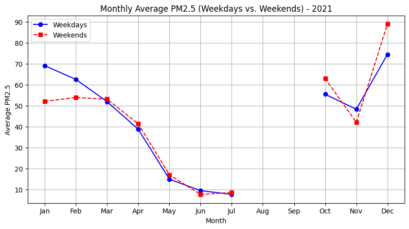

```python
df_2021 = df2[(df2['Timestamp'].dt.year == 2021) &
              (df2['station'] == "Lal Bahadur Shastri Nagar, Kalaburagi - KSPCB")].copy()

df_2021['month'] = df_2021['Timestamp'].dt.month
df_2021['day_of_week'] = df_2021['Timestamp'].dt.dayofweek  #Note: Monday=0, Sunday=6

df_2021['day_type'] = df_2021['day_of_week'].apply(lambda x: 'Weekday' if x < 5 else 'Weekend')

monthly_avg_pm25 = df_2021.groupby(['month', 'day_type'])['PM2.5'].mean().unstack()
#note the very imp function in prev line, .unstack() used to convert groupby row to column

plt.figure(figsize=(10, 5))

plt.plot(monthly_avg_pm25.index, monthly_avg_pm25['Weekday'], marker='o', linestyle='-', label='Weekdays', color='b')
plt.plot(monthly_avg_pm25.index, monthly_avg_pm25['Weekend'], marker='s', linestyle='--', label='Weekends', color='r')

# Formatting the graph
plt.xticks(range(1, 13), ['Jan', 'Feb', 'Mar', 'Apr', 'May', 'Jun', 'Jul', 'Aug', 'Sep', 'Oct', 'Nov', 'Dec'])
plt.xlabel("Month")
plt.ylabel("Average PM2.5")
plt.title("Monthly Average PM2.5 (Weekdays vs. Weekends) - 2021")
plt.legend()
plt.grid(True)

plt.show()
```

## Spatio-temporal aggregation [3 marks]

1. For each state, calculate the percentage increase or decrease in PM2.5 levels during monsoon months (June to September) compared to summer months (March to May). Which state has the most difference (increase or decrease) for the year 2022?

```python
df= pd.read_csv('Data.csv')
state=pd.read_csv('State_data.csv')
NCAP=pd.read_csv('NCAP_Funding.csv')

df['Timestamp'] = pd.to_datetime(df['Timestamp'], errors='coerce')
df_2022 = df[df['Timestamp'].dt.year == 2022]
df_2022['Month'] = df_2022['Timestamp'].dt.month
summer_months = [3, 4, 5]
monsoon_months = [6, 7, 8, 9]
df_2022_pm25 = df_2022[['PM2.5', 'Month', 'state']].dropna(subset=['PM2.5'])
monthly_avg_pm25 = df_2022_pm25.groupby(['state', 'Month']).agg({'PM2.5': 'mean'}).reset_index()
summer_data = monthly_avg_pm25[monthly_avg_pm25['Month'].isin(summer_months)]
monsoon_data = monthly_avg_pm25[monthly_avg_pm25['Month'].isin(monsoon_months)]
summer_avg = summer_data.groupby('state')['PM2.5'].mean()
monsoon_avg = monsoon_data.groupby('state')['PM2.5'].mean()
seasonal_avg = pd.merge(summer_avg, monsoon_avg, on='state', suffixes=('_summer', '_monsoon'))
seasonal_avg['percentage_change'] = ((seasonal_avg['PM2.5_monsoon'] - seasonal_avg['PM2.5_summer']) / seasonal_avg['PM2.5_summer']) * 100
max_change_state = seasonal_avg.loc[seasonal_avg['percentage_change'].abs().idxmax()]
print("State with the highest PM2.5 difference in 2022:")
print(max_change_state)
```

```
State with the highest PM2.5 difference in 2022:
PM2.5_summer         56.052160
PM2.5_monsoon        21.625728
percentage_change   -61.418564
Name: Assam, dtype: float64
```

[output not shown]

2. Plot the average PM2.5 levels for Delhi across each season (Winter: December-February, Summer: March-May, Monsoon: June-September) from 2017 to 2023. What seasonal variation, if any, can you observe in pollution levels?

[output not shown]

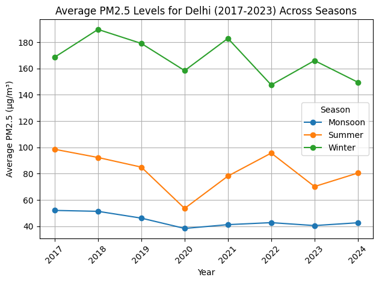

```python
delhi_data = df[df['city'] == 'Delhi']
delhi_data['Timestamp'] = pd.to_datetime(delhi_data['Timestamp'])
delhi_data['Year'] = delhi_data['Timestamp'].dt.year
delhi_data['Month'] = delhi_data['Timestamp'].dt.month
def assign_season(month):
    if month in [12, 1, 2]:
        return 'Winter'
    elif month in [3, 4, 5]:
        return 'Summer'
    elif month in [6, 7, 8, 9]:
        return 'Monsoon'
delhi_data['Season'] = delhi_data['Month'].apply(assign_season)
seasonal_avg = delhi_data.groupby(['Year', 'Season'])['PM2.5'].mean().reset_index()
seasonal_avg_pivot = seasonal_avg.pivot(index='Year', columns='Season', values='PM2.5')
seasonal_avg_pivot.plot(kind='line', marker='o')
plt.title('Average PM2.5 Levels for Delhi (2017-2023) Across Seasons')
plt.xlabel('Year')
plt.ylabel('Average PM2.5 (µg/m³)')
plt.grid(True)
plt.legend(title='Season')
plt.xticks(seasonal_avg_pivot.index, rotation=45)
plt.tight_layout()
plt.show()
```

3. Plot a time-series graph comparing Delhi’s PM2.5 levels with Mumbai’s from 2015 to 2023. Which city had more fluctuations? (Hint: Think what fluctuation means)

[output not shown]

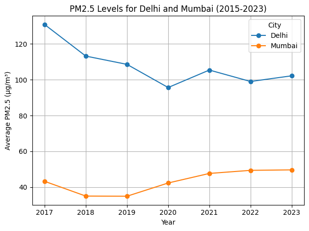

```python
df['Timestamp']=pd.to_datetime(df['Timestamp'])
df1523 = df[(df['Timestamp'].dt.year >= 2015) & (df['Timestamp'].dt.year <= 2023) & (df['city'].isin(['Delhi', 'Mumbai']))]
df1523['Year'] = df1523['Timestamp'].dt.year

df1523['Year'] = df1523['Timestamp'].dt.year

df1523_avg = df1523.groupby(['Year', 'city'])['PM2.5'].mean().reset_index()
pivot = df1523_avg.pivot(index='Year', columns='city', values='PM2.5')

pivot.plot(kind='line',marker='o')
plt.title('PM2.5 Levels for Delhi and Mumbai (2015-2023)')
plt.xlabel('Year')
plt.ylabel('Average PM2.5 (µg/m³)')
plt.grid(True)
plt.legend(title='City')
plt.tight_layout()
plt.show()
```

[output not shown]

## Population-Based [3 Marks]

1. Which state in India has the highest number of monitoring stations relative to its population?

```python
station_counts = df['state'].value_counts().reset_index()
station_counts.columns = ['State', 'Number of Stations']

merged_df = pd.merge(state, station_counts, on='State', how='inner')


merged_df['Stations per Million'] = merged_df['Number of Stations'] / (merged_df['Population'] / 1_000_000)
top_state = merged_df.loc[merged_df['Stations per Million'].idxmax()]

print("State with highest stations per million:",top_state["State"])
print("Stations per Million:", top_state["Stations per Million"])
```

```
State with highest stations per million: Chandigarh
Stations per Million: 8245.771945615614
```

2. Plot a bar chart showing the top 5 most polluted states in terms of per capita PM2.5 exposure in 2023.

[output not shown]

[output not shown]

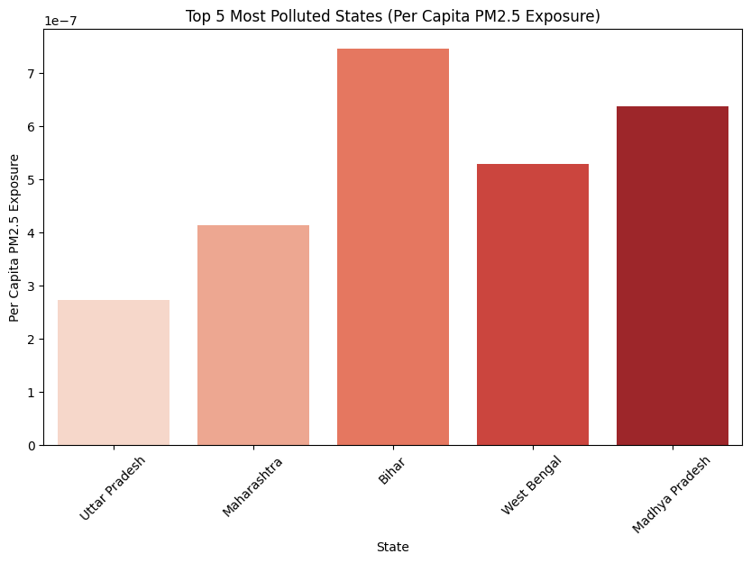

```python
df_population = pd.read_csv("State_data (2).csv")
df_PM2_5 = pd.read_csv("Data (2).csv")

df_population.rename(columns=lambda x: x.strip().lower(), inplace=True)
df_PM2_5.rename(columns=lambda x: x.strip().lower(), inplace=True)

df_PM2_5 ["date"] = pd.to_datetime(df_PM2_5["timestamp"])
date_2023 = df_PM2_5 [df_PM2_5 ["date"].dt.year == 2023]
date_2023 = date_2023.groupby("state")["pm2.5"].mean()
merged_df = pd.merge(df_population,date_2023, on="state", how="inner")


merged_df["per_capita_pm2.5"] = merged_df["pm2.5"] / merged_df["population"]
merged_df.sort_values("per_capita_pm2.5",ascending = False)

# Get the top 5 states with the highest per capita PM2.5 exposure
top_5_polluted = merged_df.head(5)

# Display the results
print("Top 5 Most Polluted States (Per Capita PM2.5 Exposure):")
print(top_5_polluted[["state", "per_capita_pm2.5"]])

# Plot the results
plt.figure(figsize=(10, 6))
sns.barplot(x="state", y="per_capita_pm2.5", data = top_5_polluted, palette="Reds")
plt.xlabel("State")
plt.ylabel("Per Capita PM2.5 Exposure")
plt.title("Top 5 Most Polluted States (Per Capita PM2.5 Exposure)")
plt.xticks(rotation=45)
plt.show()
```

3. Plot the relationship between population density and average PM2.5 concentration for each state. What conclusion can you draw about the correlation between population density and pollution? X-axis: Population density (people per square kilometer). Y-axis: Average PM2.5 concentration. Use a scatter plot to show the relationship, where each point represents a state.

[figure not shown]

```python
state_avg_Pm2_5 = df_PM2_5.groupby('state')['pm2.5'].mean()

merged_df = pd.merge(df_population, state_avg_Pm2_5, on="state", how="inner")

plt.figure(figsize=(10, 6))
sns.scatterplot(
    x=merged_df["population"],
    y=merged_df["pm2.5"],
    hue=merged_df["state"],
    palette="viridis",
    s=50
)

plt.xlabel("Population Density (people per sq km)")
plt.ylabel("Average PM2.5 Concentration")
plt.title("Relationship between Population Density and PM2.5 Concentration")
plt.legend(bbox_to_anchor=(1.05, 1), loc="upper left", title="State")
plt.grid(True)

plt.show()
```

```python
print(df)
print(state)
```

[output not shown]

[output cut: 57 more lines]

Area Based [3 Marks]

1. Which state has the highest PM2.5 concentration per square kilometer? Plot the pollution levels for all states relative to their area. X-axis: States. Y-axis: PM2.5 concentration per square kilometer. Use a bar plot where each bar represents a state, and the height shows PM2.5 per sq km.

```
Maximum= Chandigarh 0.49707721560304186
```

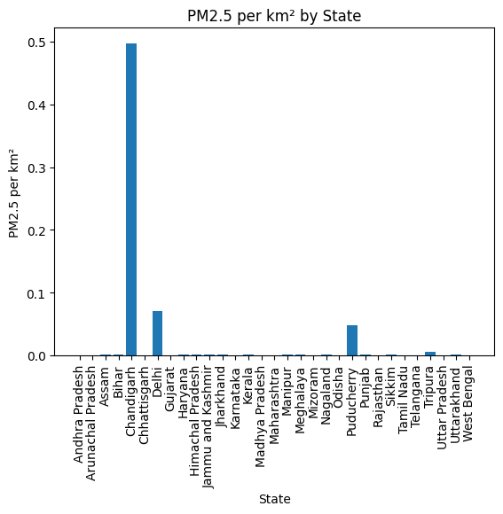

```python
by_area=state.groupby(['State'])['Area (km2)'].max()

max_PM25=df.groupby(['state'])['PM2.5'].mean()

y=max_PM25/by_area

print("Maximum=",y.idxmax(),y.max())

plt.bar(y.index, y.values)
plt.xlabel('State')
plt.ylabel('PM2.5 per km²')
plt.title('PM2.5 per km² by State')
plt.xticks(rotation=90)
plt.show()
```

2. Compare the total number of monitoring stations per square kilometer in each state. Identify the state with the highest density of monitoring stations relative to its area. Show a bar plot where each bar represents a state, and the height shows the number of monitoring stations per square kilometer.

```
highest density of stations= Delhi 0.026954177897574125
```

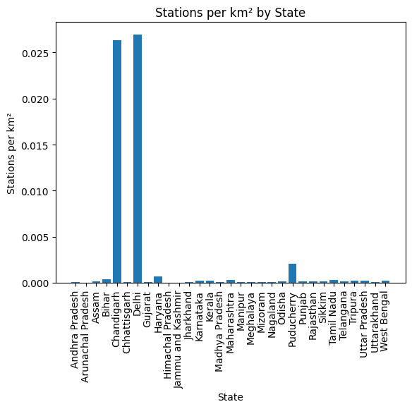

```python
t=df.groupby(['state'])['station'].nunique()
by_area=state.groupby(['State'])['Area (km2)'].max()

per_sqkm=t/by_area

print("highest density of stations=",per_sqkm.idxmax(),per_sqkm.max())
plt.bar(per_sqkm.index, per_sqkm.values)
plt.xlabel('State')
plt.ylabel('Stations per km²')
plt.title('Stations per km² by State')
plt.xticks(rotation=90)
plt.show()
```

3. Compare the average PM2.5 levels between Maharashtra and Madhya Pradesh over the year 2021. Given that both states have similar area sizes but different population densities, analyze how population density impacts pollution levels in these two states.

```python
filter=df[(df['Timestamp'].dt.year ==2021)&(df['state'].isin(['Maharashtra', 'Madhya Pradesh']))]
f=filter.groupby(['state'])['PM2.5'].mean()
print("Average PM2.5 levels Maharashtra and Madhya Pradesh year 2021=\n",f)

state_m=state[state['State'].isin(['Maharashtra', 'Madhya Pradesh'])]
state_m=state_m.set_index('State')
t=df[(df['state'].isin(['Maharashtra', 'Madhya Pradesh']))]
avg_pm25=t.groupby(['state'])['PM2.5'].mean()
p_density=state_m['Population']/state_m['Area (km2)']



d = pd.concat([p_density, avg_pm25], axis='columns')
d.columns = ['Population Density', 'PM2.5']

print("Population density and average PM2.5=\n", d)
```

```
Average PM2.5 levels Maharashtra and Madhya Pradesh year 2021=
 state
Madhya Pradesh    47.095952
Maharashtra       46.440044
Name: PM2.5, dtype: float64
Population density and average PM2.5=
                 Population Density      PM2.5
Maharashtra             365.192023  43.491415
Madhya Pradesh          235.608557  45.874375
```

## Funding Based [3 Marks]

1. Compare the average PM2.5 levels between states that received NCAP funding and those that did not in 2021.

```python
df['Timestamp'] = pd.to_datetime(df['Timestamp'])
df_2021 = df[df['Timestamp'].dt.year == 2021]

state_avg_pm25 = df_2021.groupby('state')['PM2.5'].mean().reset_index()

# Get unique states that received funding
# Convert funding column to numeric (forcing errors to NaN)
NCAP['Amount released during FY 2020-21'] = pd.to_numeric(NCAP['Amount released during FY 2020-21'], errors='coerce')

# Filter
funded_states_2021 = NCAP[NCAP['Amount released during FY 2020-21'] > 0]['State'].unique()
# Add a column for funds
state_avg_pm25['Funds'] = state_avg_pm25['state'].apply(lambda x: 'Funded' if x in funded_states_2021 else 'Not Funded')
pm25_comparison = state_avg_pm25.groupby('Funds')['PM2.5'].mean()

print("Average PM2.5 levels in 2021:")
print(pm25_comparison)
```

```
Average PM2.5 levels in 2021:
Funds
Funded        45.508872
Not Funded    42.982646
Name: PM2.5, dtype: float64
```

2. Create a time series plot showing PM2.5 levels with an increment in NCAP funding for Assam. Has an increment of the financing led to noticeable improvements in air quality?

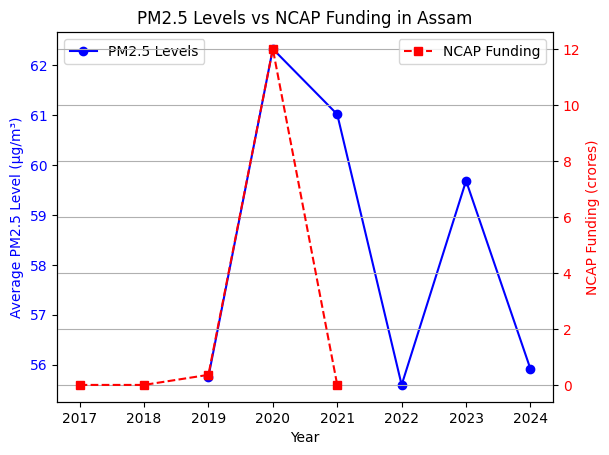

```python
dffund=pd.read_csv('NCAP_Funding (2).csv')
df_assam = df[df['state'] == 'Assam']
df_assam_monthly = df_assam.groupby(pd.to_datetime(df_assam['Timestamp']).dt.year)['PM2.5'].mean()
df_funding_assam = dffund[dffund['State'] == 'Assam']

funding_years = ['Amount released during FY 2019-20', 'Amount released during FY 2020-21', 'Amount released during FY 2021-22']
df_funding_assam.loc[:,funding_years] = df_funding_assam[funding_years].apply(pd.to_numeric, errors='coerce')

# Create a cumulative funding timeline
funding_amounts = df_funding_assam[funding_years].sum()
# Extract funding amounts
funding_timeline = pd.DataFrame({
    'Year': [2017, 2018, 2019, 2020, 2021],  # **Added 2017 and 2018**
    'NCAP Funding (crores)':pd.concat([pd.Series([0,0]),funding_amounts])  # **Prepend two zeros**
})

# Convert years to datetime for proper plotting
fig,ax1=plt.subplots()
# Plot PM2.5 trend
ax1.plot(df_assam_monthly.index, df_assam_monthly, color='b', marker='o', linestyle='-', label='PM2.5 Levels')
ax1.set_xlabel("Year")
ax1.set_ylabel("Average PM2.5 Level (µg/m³)", color='b')
ax1.tick_params(axis='y', labelcolor='b')

# Add second y-axis for funding increments
ax2 = ax1.twinx()
ax2.plot(funding_timeline['Year'], funding_timeline['NCAP Funding (crores)'], color='r', marker='s', linestyle='--', label='NCAP Funding')
ax2.set_ylabel("NCAP Funding (crores)", color='r')
ax2.tick_params(axis='y', labelcolor='r')

# Adjust X-axis to start from 2017
#ax1.set_xlim(pd.Timestamp('2017-01-01'), pd.Timestamp('2022-01-01'))

# Titles & Legends
plt.title("PM2.5 Levels vs NCAP Funding in Assam")
ax1.legend(loc='upper left')
ax2.legend(loc='upper right')
plt.grid()
plt.show()
```

3. Create a scatter plot to showcase the area versus funding received by a state. Mark every state with a different color and show the legend outside the plot.

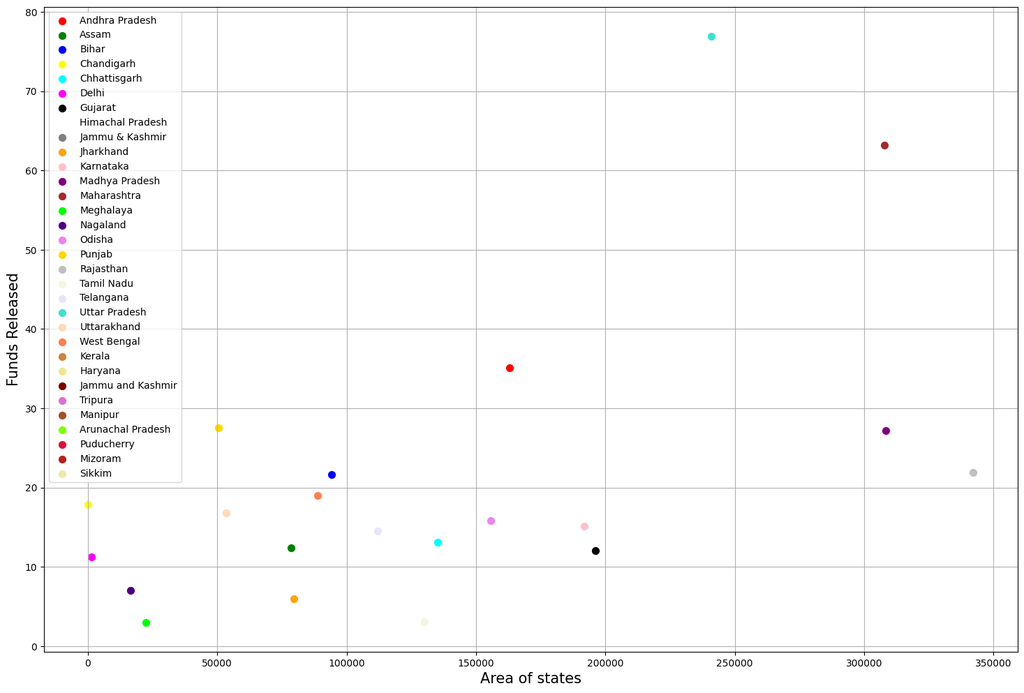

```
32
```

```python
import numpy as np
total_funding=NCAP.groupby('State')['Total fund released'].sum()
state_area=state.set_index('State')['Area (km2)']
df_data=pd.concat([total_funding,state_area],axis='columns')
df_data
total_fund_released=df_data['Total fund released']
area_km2=df_data['Area (km2)']
c=np.random.randint(1,100,len(df_data.index))
fig1,ax1 = plt.subplots(figsize=(18,12))
colours=colors= [
    'red', 'green', 'blue', 'yellow', 'cyan', 'magenta', 'black', 'white',
    'gray', 'orange', 'pink', 'purple', 'brown', 'lime', 'indigo', 'violet',
    'gold', 'silver', 'beige', 'lavender', 'turquoise', 'peachpuff', 'coral',
    'peru', 'khaki', 'maroon', 'orchid', 'sienna', 'chartreuse', 'crimson', 'firebrick','palegoldenrod'
]
for i in range(len(df_data.index)):
    ax1.scatter(area_km2.iloc[i],total_fund_released.iloc[i],c=colours[i],s=50,label=df_data.index[i])
ax1.grid()
ax1.legend()
ax1.set_xlabel('Area of states',fontsize=15)
ax1.set_ylabel('Funds Released',fontsize=15)
plt.show()
print(len(df_data.index))
```

Miscellaneous Questions [5 Marks]